# (PSL) Coding Assignment 2

## Part I: Implement Lasso

### One-variable Lasso

First write a function `one_var_lasso` that takes the following inputs:

$$\mathbf{v}=(v_1, \dots, v_n)^t, \quad
\mathbf{z} = (z_1, \dots, z_n)^t, \quad \lambda > 0$$
and solves the following one-variable Lasso problem:
$$\min_{b} \frac{1}{2n} \sum_{i=1}^n (v_i - b z_i)^2 +\lambda | b | =
\min_{b} \frac{1}{2n} \| \mathbf{v} - b \cdot \mathbf{z}\|^2 +
\lambda | b |.$$

```r
one_var_lasso = function(r, z, lam) {

  ##############################
  # YOUR CODE
  ##############################
}
```

### The CD Algorithm

Next write your own function `MyLasso` to implement the **Coordinate Descent (CD)** algorithm by repeatedly calling `one_var_lasso`.

Your function may look like the following.

```r
MyLasso = function(X, y, lam.seq, maxit = 100) {

    # Input
    # X: n-by-p design matrix without the intercept
    # y: n-by-1 response vector
    # lam.seq: sequence of lambda values (arranged from large to small)
    # maxit: number of updates for each lambda

    # Output
    # B: a (p+1)-by-length(lam.seq) coefficient matrix
    #    with the first row being the intercept sequence

    n = length(y)
    p = dim(X)[2]
    nlam = length(lam.seq)
    B = matrix(0, ncol = nlam, nrow = (p+1))
    rownames(B) = c("Intercept", colnames(X))

    ##############################
    # YOUR CODE:
    # (1) new.X = centered & scaled X;
    # (2) record the centers and scales used in (1)
    ##############################

    # Initialize coef vector b and residual vector r
    b = rep(0, p)
    r = y

    # Triple nested loop
    for (m in 1:nlam) {
      for (step in 1:maxit) {
        for (j in 1:p) {
          r = r + (new.X[, j] * b[j])
          b[j] = one_var_lasso(r, new.X[, j], lam.seq[m])
          r = r - new.X[, j] * b[j]
        }
      }
      B[-1, m] = b
    }

    ##############################
    # YOUR CODE:
    # scale back the coefficients;
    # update the intercepts stored in B[1, ]
    ##############################

    return(B)
}
```

### Test Your Function

Test your `MyLasso` function on data set `Coding2_Data0.csv` with the following lambda sequence.

Your function should output estimated Lasso coefficients similar to the ones returned by R with option **`standardized = TRUE`**.

```r
myData = read.csv("Coding2_Data0.csv")
X = as.matrix(myData[, -14])
y = myData$Y
lam.seq = exp(seq(-1, -8, length.out = 80))
myout = MyLasso(X, y, lam.seq)
```

- Check the accuracy of your function against the output from `glmnet`. The maximum difference between the two coefficient matrices should be less than 0.005.

```r
library(glmnet)
lasso.fit = glmnet(X, y, alpha = 1, lambda = lam.seq)
max(abs(coef(lasso.fit) - myout))
```

- Produce a path plot for the 13 non-intercept coefficients along the lambda values in log scale.

```r
x.index = log(lam.seq)
beta = myout[-1, ]  # beta is a 13-by-80 matrix
matplot(x.index, t(beta),
        xlim = c(min(x.index), max(x.index)),
        lty = 1,
        xlab = "Log Lambda",
        ylab = "Coefficients",
        type="l",
        lwd = 1)
# You can add variable names to each path
var.names = colnames(X)
nvar = length(var.names)
xpos = rep(min(x.index), nvar)
ypos = beta[, ncol(beta)]
text(xpos, ypos, var.names, cex=0.5, pos=2)
```

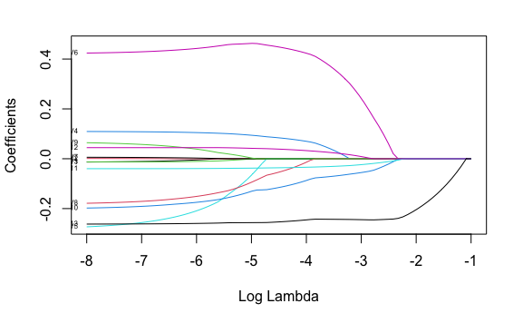

Your plot should look almost the same as the plot from `glmnet`

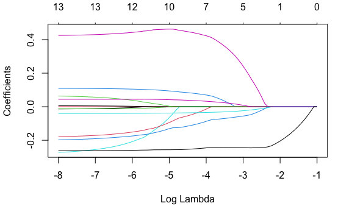

```r
plot(lasso.fit, xvar = "lambda")
```

## Part II: Simulation Study

### Case I

Load libraries and data.

```r
library(glmnet)
library(pls)
myData = read.csv("Coding2_Data1.csv", header = TRUE)
```

Some algorithms need the matrix/vector input (instead of a data frame)

```r
X = data.matrix(myData[,-1])
Y = myData[,1]
```

We will repeat the simulation 50 times. In each iteration, randomly split the data into two parts, 75% for training and 25% for testing. You can write a loop with 50 iterations, and in each iteration, split the data and run the **six** procedures (**five** procedures for case II).

Or you can save the row IDs for the 50 test data sets, then write a separate loop for each method. Using `all.test.id` (produced below), you can ensure that you use the same training/test split for each procedure.

```r
T = 50
n = length(Y)
ntest = round(n * 0.25)  # test set size
ntrain = n - ntest  # training set size
all.test.id = matrix(0, ntest, T)  #
for(t in 1:T){
  all.test.id[, t] = sample(1:n, ntest)
}
#save(all.test.id, file="alltestID.RData")
```

Next, let’s try the six procedures using the first split.

### Full Model

```r
test.id = all.test.id[, 1]
full.model = lm(Y ~ ., data = myData[-test.id, ])
Ytest.pred = predict(full.model, newdata = myData[test.id, ])
mean((myData$Y[test.id] - Ytest.pred)^2)
```

### Ridge

The default lambda sequence for Case I might be too large. Consider providing a sequence that covers smaller lambda values as `mylasso.lambda.seq` below.

```r
mylasso.lambda.seq = exp(seq(-10, 1, length.out = 100))
cv.out = cv.glmnet(X[-test.id, ], Y[-test.id], alpha = 0,
                   lambda = mylasso.lambda.seq)

best.lam = cv.out$lambda.min
Ytest.pred = predict(cv.out, s = best.lam, newx = X[test.id, ])
mean((Y[test.id] - Ytest.pred)^2)
```

### Lasso

```r
cv.out = cv.glmnet(X[-test.id, ], Y[-test.id], alpha = 1)
best.lam = cv.out$lambda.min
Ytest.pred = predict(cv.out, s = best.lam, newx = X[test.id, ])
mean((Y[test.id] - Ytest.pred)^2)

best.lam = cv.out$lambda.1se
Ytest.pred = predict(cv.out, s = best.lam, newx = X[test.id, ])
mean((Y[test.id] - Ytest.pred)^2)

# Lasso refit
mylasso.coef = predict(cv.out, s = best.lam, type = "coefficients")
var.sel = row.names(mylasso.coef)[which(mylasso.coef != 0)[-1]]
mylasso.refit = lm(Y ~ ., myData[-test.id, c("Y", var.sel)])
Ytest.pred = predict(mylasso.refit, newdata = myData[test.id, ])
mean((Ytest.pred - Y[test.id])^2)
```

### PCR

The principle components regression command, `pcr`, returns both the CV errors and the adjusted CV errors. For the definition of adjusted CV used in `pcr`, check Sec 2.4 of [this paper](https://mevik.net/work/publications/MSEP_estimates.pdf); we use CV error below.

The default `pcr` does not scale the input features. Try `pcr(...., scale=TRUE)`

```r
mypcr = pcr(Y ~ ., data= myData[-test.id, ], validation="CV", scale=TRUE)
CVerr = RMSEP(mypcr)$val[1, , ]
adjCVerr = RMSEP(mypcr)$val[2, , ]
best.ncomp = which.min(CVerr) - 1

if (best.ncomp==0) {
    Ytest.pred = mean(myData$Y[-test.id])
  } else {
    Ytest.pred = predict(mypcr, myData[test.id,], ncomp=best.ncomp)
  }
mean((Ytest.pred - myData$Y[test.id])^2)
```

Note that we have to subtract one from `which.min(CVerr)` since the 1st column of the CV table corresponds to the CV error with zero component (i.e., the model with just the intercept) and the k-th column of the CV table corresponds to (k-1) components.

The prediction function does not seem to work when `best.ncomp = 0`. So we have to handle that case separately.